# Random Forest Final Model

[GitHub](https://github.com/elenabagnera/CapitalBikesProject)

## Comparing RMSEs of our models

Random forests does better than decision tree and LASSO models in terms of RMSE.

- Decision tree lowest RMSE - 4.25
- Random Forest - 3.82
- LASSO lowest RMSE - 4

### Potential reasons for Random Forests out-performing decision trees and LASSO

Having a group of decision trees creates “randomness” and avoids common weaknesses in predictions based on one decision tree over fitting and excessive correlation between variables. This is because

1. random forest algorithm uses a subset of features as candidates at each split (does not rely on the same set of features: de-correlates individual trees)
2. Each tree uses a random sample from the training dataset as it generates the splits which inserts an aspect of randomness and prevents overfitting

Compared to LASSO regression, Random forests decision trees are great for obtaining non-linear relationships between input features and the target variable.

RF also operates within sample, as opposed to LASSO models which could potentially provide out of sample predictions. In our case, this might be risky because we can not have negative departures, and since departures could go to very high levels in general, we should be careful in analyzing predictions that give very high hourly departure estimation which could be unrealistic. Although we expected LASSO to do a better job in avoiding multicollinearity between our predictors, it is difficult to judge for sure.

## Random Forest on the Test Data

```r
lagged_data <- read_csv('lagged_data_3200.csv')
hour_data <- read_csv('hour_data_3200.csv') # Used for graphs

model_data <- lagged_data %>%
  add_predictor_times() %>%
  filter(!is.na(departures) & !is.na(arrivals)) %>%
  # Having real time arrival data would be cheating
  select(-arrivals) %>%
  format_weather()
```

```r
set.seed(28021995)

# create a split object
data_split <- initial_split(model_data, prop = 0.8)

# create the training and testing data
train <- training(x = data_split)
test  <- testing(x = data_split)
```

```r
recipe <-
  recipe(formula = departures ~ ., data = train) %>%
  step_holiday(date, holidays = timeDate::listHolidays("US"), keep_original_cols = FALSE) %>%
  step_nzv(all_predictors())
  # step_BoxCox(all_outcomes()) # Does not run with zero in the values
```

## Model Implementation

min_n left to default.

```r
# Tuning min_n doesn't seem to help
mod <- rand_forest(mtry = 250, trees = 1000) %>%
  set_mode("regression") %>%
  set_engine("ranger")

wf <- workflow() %>%
  add_recipe(recipe) %>%
  add_model(mod)
```

```r
final_wf <- workflow() %>%
  add_recipe(recipe) %>%
  add_model(mod) %>%
  fit(train)

p_test <- bind_cols(
  test,
  predict(object = final_wf, new_data = test))
```

## Results

Out of sample RMSE

```r
sqrt(mean((p_test$departures - p_test$.pred)^2))
```

```
## [1] 3.713051
```

```r
write_csv(p_test, "final-p-test.csv")
```

```r
mod %>%
  set_engine("ranger", importance = "permutation") %>%
  fit(departures ~ .,
    data = train
  ) %>%
  vip(geom = "point")
```

[output not shown]

1. Hour: as expected, the hour has a big influence on predicting departures at Lincoln Memorial Station. We know from the exploration period that there is some hours *(1-6 am)* where departures are nearly non existance, compared to peaking in the evening around *(2 pm)*
2. Year day: It is likely that year day affects departures because it reflects seasons which has many implications, including but not limited to weather changes due to seasons, but also other periods like the summer holidays.
3. Sun: Our results also suggest that departures are associated with sunlight. This is reasonable given that people are more likely to ride bikes duirng daylight. This could also be a redundant variable with hour given too much weight to the time of day.
4. Week day: From earlier data exploration we could see that weekdays have a strong relationship with departures (less departures during weekends). This is a reasonable prediction.
5. 4th Street and Maddison DR. Station departures and arrivals: This suggests that a lot trips go back and forth between Lincoln Memorial Station and 4th Street and Maddison Dr. Station or simply that if that nearby station is receiving a lot of traffic, so too is the Lincoln Memorial. Trips back and forth from near the Smithonian to Lincoln Memorial seem popular among Capital Bikeshare riders.

## Discussion of Results

### Average departure per hour

```r
p_test %>% summarize(mean(departures))
```

```
## # A tibble: 1 × 1
##   `mean(departures)`
##                <dbl>
## 1               3.45
```

The average departures per hour are `3.45`. Therefore an RMSE > 3.45 appears to not be very good. Lets look at the areas where the predicitions are poor.

### Top 20 hours of 12431 hours.

```r
p_test %>% arrange(-departures) %>% select(departures) %>% head(20)
```

```
## # A tibble: 20 × 1
##    departures
##         <dbl>
##  1         35
##  2         34
##  3         34
##  4         32
##  5         31
##  6         31
##  7         30
##  8         28
##  9         27
## 10         27
## 11         27
## 12         27
## 13         27
## 14         26
## 15         25
## 16         25
## 17         25
## 18         25
## 19         25
## 20         24
```

### Top 20 Error

Below is our largest error.

- The Error column shows how many `rides / hour` the model missed by for that given hour.
- The departures column shows the actual number of departures
- the .pred column shows what the model predicted
- All other columns (lincoln_memorial_x, weather, temperature, etc are lagged two weeks)

```r
p_test %>%
  mutate(error = abs(.pred - departures)) %>%
  select(year, month, day, hour, weekday, departures, .pred, error, conditions,temperature, cloud_cover, snow, precipitation, lincoln_memorial_departures) %>%
  arrange(-error) %>%
  head(20)
```

```
## # A tibble: 20 × 14
##     year month   day  hour weekday departures .pred error conditions temperature
##    <dbl> <chr> <dbl> <dbl> <ord>        <dbl> <dbl> <dbl> <chr>            <dbl>
##  1  2020 Aug      30    13 Sun             34  7.44  26.6 Good              71.8
##  2  2021 Mar      21    15 Sun             35  8.66  26.3 Good              46.8
##  3  2021 May      31    11 Mon             31  5.71  25.3 Okay              68.1
##  4  2021 Jul       5    13 Mon             31  6.67  24.3 Okay              86.1
##  5  2021 Apr       4    19 Sun             32  7.88  24.1 Good              57.8
##  6  2021 Mar      27    11 Sat             30  9.38  20.6 Good              51.9
##  7  2021 May      30    17 Sun             27  7.38  19.6 Okay              63.1
##  8  2020 Aug       9    13 Sun             28  8.68  19.3 Good              92.8
##  9  2020 Jun      27    15 Sat             34 15.6   18.4 Good              79
## 10  2021 May      28    13 Fri             26  7.84  18.2 Okay              69
## 11  2021 May      29    14 Sat              0 18.2   18.2 Good              76.6
## 12  2021 Mar      30    18 Tue             27  9.08  17.9 Okay              44.7
## 13  2021 Jan      16    14 Sat              0 17.5   17.5 Okay              56.9
## 14  2020 May      25    11 Mon             20  3.31  16.7 Okay              57.3
## 15  2020 Sep       6    17 Sun             27 10.3   16.7 Good              88
## 16  2021 Jul      28    12 Wed             21  5.18  15.8 Good              89.9
## 17  2021 May      31    18 Mon             24  8.35  15.7 Okay              73.8
## 18  2021 Apr      24    15 Sat              4 18.5   14.5 Okay              71.1
## 19  2021 May      31     9 Mon             16  1.84  14.2 Good              63
## 20  2020 Aug      30    14 Sun             24  9.97  14.0 Okay              73
## # … with 4 more variables: cloud_cover <dbl>, snow <dbl>, precipitation <dbl>,
## #   lincoln_memorial_departures <dbl>
```

### Best guesses

The model predicts very well at 2-5 AM.

```r
p_test %>%
  mutate(error = abs(.pred - departures)) %>%
  select(year, month, day, hour, weekday, departures, .pred, error, conditions,temperature, cloud_cover, snow, precipitation, lincoln_memorial_departures)  %>%
  arrange(error) %>%
  head(15)
```

```
## # A tibble: 15 × 14
##     year month   day  hour weekday departures .pred error conditions temperature
##    <dbl> <chr> <dbl> <dbl> <ord>        <dbl> <dbl> <dbl> <chr>            <dbl>
##  1  2020 May      16     3 Sat              0     0     0 Good              53.9
##  2  2020 May      19     3 Tue              0     0     0 Okay              52.9
##  3  2020 May      23     5 Sat              0     0     0 Good              37.9
##  4  2020 May      25     4 Mon              0     0     0 Okay              51.5
##  5  2020 May      28     3 Thu              0     0     0 Good              52.3
##  6  2020 May      29     4 Fri              0     0     0 Good              63
##  7  2020 Jun      17     2 Wed              0     0     0 Okay              68.7
##  8  2020 Jun      26     4 Fri              0     0     0 Okay              73
##  9  2020 Aug       4     4 Tue              0     0     0 Good              78.7
## 10  2020 Sep      10     3 Thu              0     0     0 Okay              74.6
## 11  2020 Sep      19     5 Sat              0     0     0 Good              65.8
## 12  2020 Sep      24     3 Thu              0     0     0 Okay              75.7
## 13  2020 Oct       3     4 Sat              0     0     0 Good              52.8
## 14  2020 Oct       6     3 Tue              0     0     0 Good              50.4
## 15  2020 Oct       9     3 Fri              0     0     0 Okay              63.6
## # … with 4 more variables: cloud_cover <dbl>, snow <dbl>, precipitation <dbl>,
## #   lincoln_memorial_departures <dbl>
```

### Best guesses with more 5 departures

```r
p_test %>%
  mutate(error = abs(.pred - departures)) %>%
  filter(departures > 5) %>%
  select(year, month, day, hour, weekday, departures, .pred, error, conditions,temperature, cloud_cover, snow, precipitation, lincoln_memorial_departures)  %>%
  arrange(error) %>%
  head(15)
```

```
## # A tibble: 15 × 14
##     year month   day  hour weekday departures .pred  error conditions
##    <dbl> <chr> <dbl> <dbl> <ord>        <dbl> <dbl>  <dbl> <chr>
##  1  2021 Jun       5    17 Sat             13 13.0  0.0272 Okay
##  2  2021 Mar      25    14 Thu              7  6.96 0.0380 Good
##  3  2020 Jul      22    21 Wed              6  6.04 0.0402 Good
##  4  2020 Jun       7    14 Sun             12 11.9  0.0512 Okay
##  5  2021 Aug       4    21 Wed              7  7.06 0.0605 Good
##  6  2021 Jul      12    13 Mon              7  6.94 0.0609 Good
##  7  2021 Jul      22    17 Thu              7  7.06 0.0627 Good
##  8  2020 Oct       8    18 Thu              8  7.93 0.0715 Good
##  9  2020 Nov      10    18 Tue              6  6.07 0.0747 Okay
## 10  2021 Sep      19    14 Sun             14 14.1  0.0763 Okay
## 11  2021 Aug      12    19 Thu              7  7.09 0.0861 Okay
## 12  2020 Jun      11    20 Thu              6  6.09 0.0925 Good
## 13  2021 Jun      18    21 Fri              7  6.90 0.103  Good
## 14  2020 Jul      28    18 Tue              8  7.89 0.107  Good
## 15  2020 Jul      24    16 Fri              7  6.87 0.127  Good
## # … with 5 more variables: temperature <dbl>, cloud_cover <dbl>, snow <dbl>,
## #   precipitation <dbl>, lincoln_memorial_departures <dbl>
```

### Worst guessing with low departures - why?

We decided to investigate poor guesses with low actual departures. We realized a large issue with our modeling that does not effect other prediction models as much - weather. Weather will highly affect if a person rides a bike. And our model has no way of knowing the *actual* weather on the hour of the ride. It only knows the lagged weather.

```r
p_test %>%
  mutate(error = abs(.pred - departures)) %>%
  filter(departures < 5) %>%
  select(year, month, day, hour, weekday, departures, .pred, error, conditions,temperature, cloud_cover, snow, precipitation, lincoln_memorial_departures)  %>%
  arrange(-error) %>%
  head(15)
```

```
## # A tibble: 15 × 14
##     year month   day  hour weekday departures .pred error conditions temperature
##    <dbl> <chr> <dbl> <dbl> <ord>        <dbl> <dbl> <dbl> <chr>            <dbl>
##  1  2021 May      29    14 Sat              0  18.2 18.2  Good              76.6
##  2  2021 Jan      16    14 Sat              0  17.5 17.5  Okay              56.9
##  3  2021 Apr      24    15 Sat              4  18.5 14.5  Okay              71.1
##  4  2021 Aug      14    15 Sat              3  16.6 13.6  Okay              80
##  5  2020 Jun      28    14 Sun              2  14.8 12.8  Good              75.5
##  6  2021 Apr      18    18 Sun              2  14.7 12.7  Good              71.9
##  7  2021 Aug       1    14 Sun              1  13.4 12.4  Okay              81.1
##  8  2021 Jul       4    12 Sun              0  12.1 12.1  Okay              84.9
##  9  2021 Sep      21    16 Tue              1  12.4 11.4  Okay              85.8
## 10  2021 Aug      29    17 Sun              0  10.8 10.8  Okay              82.6
## 11  2020 Nov       7    18 Sat              1  11.7 10.7  Okay              69.2
## 12  2020 Jun       8    13 Mon              0  10.5 10.5  Good              71.6
## 13  2021 Apr      25    11 Sun              1  11.3 10.3  Good              73.1
## 14  2020 Sep      13    15 Sun              4  14.3 10.3  Okay              81.9
## 15  2021 Apr      13    15 Tue              1  10.8  9.81 Good              68
## # … with 4 more variables: cloud_cover <dbl>, snow <dbl>, precipitation <dbl>,
## #   lincoln_memorial_departures <dbl>
```

### Worst guesses with low departures and actual weather

The data below rejoins the predictions with the actual weather. The data below is *not* lagged.

You will see that either winds, rain, or cloud cover likely caused these low rides.

```r
p_test_no_wx <- p_test %>%
    mutate(error = abs(.pred - departures)) %>%
  select(year, month, day, hour, weekday, departures, .pred, error, lincoln_memorial_departures)

hour_data_wx <- hour_data %>%
  select(year, month, day, hour, conditions,temperature, cloud_cover, precipitation, wind_speed, heat_index, wind_chill)

left_join(p_test_no_wx, hour_data_wx, on=c(year, month, day, hour)) %>%
  filter(departures < 5) %>%
  arrange(-error) %>%
  head(15)
```

```
## # A tibble: 15 × 16
##     year month   day  hour weekday departures .pred error lincoln_memorial_depa…
##    <dbl> <chr> <dbl> <dbl> <ord>        <dbl> <dbl> <dbl>                  <dbl>
##  1  2021 May      29    14 Sat              0  18.2 18.2                      14
##  2  2021 Jan      16    14 Sat              0  17.5 17.5                      12
##  3  2021 Apr      24    15 Sat              4  18.5 14.5                      36
##  4  2021 Aug      14    15 Sat              3  16.6 13.6                      13
##  5  2020 Jun      28    14 Sun              2  14.8 12.8                      13
##  6  2021 Apr      18    18 Sun              2  14.7 12.7                      22
##  7  2021 Aug       1    14 Sun              1  13.4 12.4                      11
##  8  2021 Jul       4    12 Sun              0  12.1 12.1                      10
##  9  2021 Sep      21    16 Tue              1  12.4 11.4                      15
## 10  2021 Aug      29    17 Sun              0  10.8 10.8                       9
## 11  2020 Nov       7    18 Sat              1  11.7 10.7                      11
## 12  2020 Jun       8    13 Mon              0  10.5 10.5                      16
## 13  2021 Apr      25    11 Sun              1  11.3 10.3                       9
## 14  2020 Sep      13    15 Sun              4  14.3 10.3                      20
## 15  2021 Apr      13    15 Tue              1  10.8  9.81                     24
## # … with 7 more variables: conditions <chr>, temperature <dbl>,
## #   cloud_cover <dbl>, precipitation <dbl>, wind_speed <dbl>, heat_index <dbl>,
## #   wind_chill <dbl>
```

```r
p_test %>% summarize(mean(wind_speed))
```

```
## # A tibble: 1 × 1
##   `mean(wind_speed)`
##                <dbl>
## 1               7.99
```

### Can we predict Lincoln Memorial will be empty?

The initial goal of this project was to predict when a station would be empty. However, the data does not support knowing the actual number of spots available at a station. We were curious if the model would predict lower values for departures at times the station would likely be empty. Below is a high volume day.

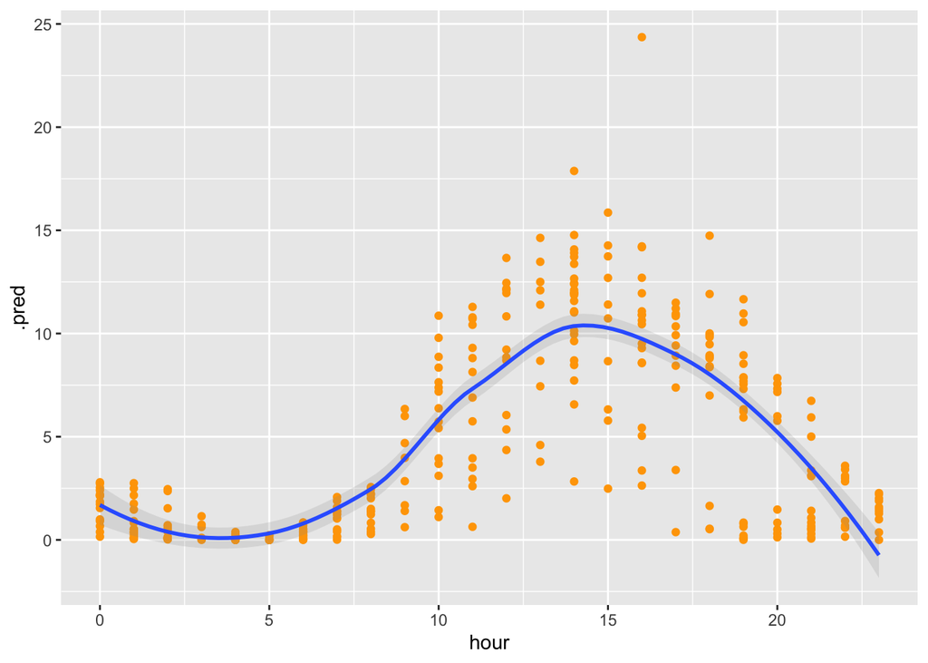

```r
p_test %>%
  filter(weekday == "Sun") %>%
  ggplot(aes(x = hour, y = .pred))+
  geom_point(color = "orange") +
  geom_smooth(alpha=0.2)
```

It does not appear easy to predict for the lincoln_memorial station. But that station is also not empty very often.

### Why the variance for a given hour on a Sunday?

We tested if perhaps the low values were actually predicting an empty station. We focused on 2 PM on Sunday, which is one of the highest demand times.

After graphing the results over many of the predictors we found that the departures and arrivals, two weeks lagged, for 4th St and Madison / the Lincoln Memorial were strong correlators to the variance in a given hour. Below is the graph showing that.

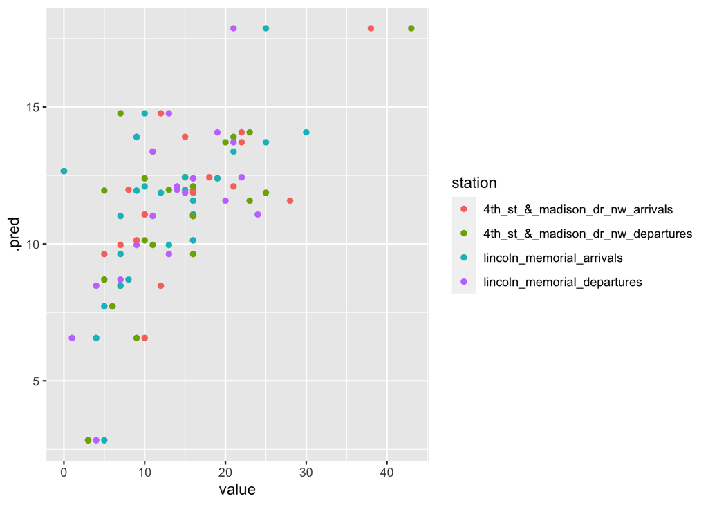

```r
p_test %>%
  filter(weekday == "Sun", hour == 14) %>%
  select(`4th_st_&_madison_dr_nw_arrivals`, `4th_st_&_madison_dr_nw_departures`, `lincoln_memorial_departures`, lincoln_memorial_arrivals, .pred) %>%
  pivot_longer(1:4, names_to = "station", values_to="value") %>%
  ggplot(aes(x = value, y = .pred, color=station))+
  geom_point()
```

### Filtering out the Daylight Savings Time data point and showing the trends

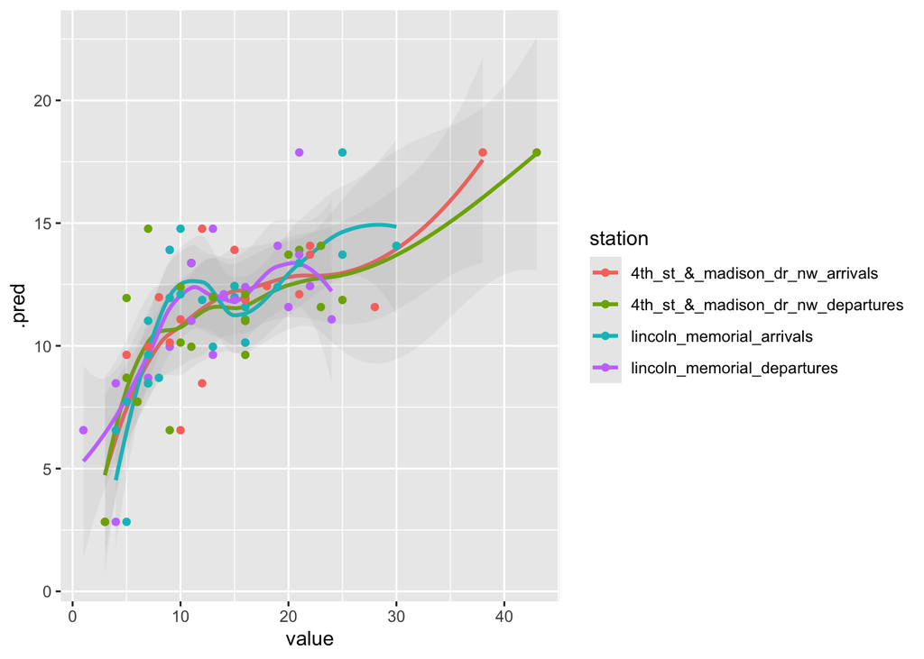

```r
# Only having one data point for certain times of the year hurts
# That one high datapoint is daylight savings time....
# only 23 hours in that day
p_test %>%
  filter(weekday == "Sun", hour == 14) %>%
  select(`4th_st_&_madison_dr_nw_arrivals`, `4th_st_&_madison_dr_nw_departures`, `lincoln_memorial_departures`, lincoln_memorial_arrivals, .pred) %>%
  pivot_longer(1:4, names_to = "station", values_to="value") %>%
  filter(value >= 1) %>%
  ggplot(aes(x = value, y = .pred, color=station))+
  geom_smooth(aes(x = value, y = .pred, color=station), alpha=0.1)+
  geom_point()
```

```r
# Look at Georgetown Harbor / 30th St NW
# 39th & Calvert St NW / Stoddert
```

Having two or more years would likely have helped whic did not have a large change due to COVID. Many of the large variances were Oct-March, where we have a single data point since our data covers approximately 17 months.

## High Supply

To investigate more on if we could predict if a station would be empty or full we analyzed a very high supply station and a very high demand station. Below sithe high supply.

```r
cbs_data <- read_files('data/')

data <- sep_departures_from_arrivals(cbs_data) %>%
  filter(!is.na(station)) # Remove electric bikes not going to / from a station

filtered_data <- filter_by_distance(data, from_station = 'georgetown_harbor_/_30th_st_nw', distance_m = 1600)

hour_data <- get_station_hourly(filtered_data) %>%
  get_historic_weather() %>%
  add_sun_is_out()

lagged_data <- setup_for_time_prediction(hour_data, station_name = "georgetown_harbor_/_30th_st_nw")

model_data <- lagged_data %>%
  add_predictor_times() %>%
  filter(!is.na(departures) & !is.na(arrivals)) %>%
  select(-departures) %>%
  format_weather()

# create a split object
data_split <- initial_split(model_data, prop = 0.8)

# create the training and testing data
train <- training(x = data_split)
test  <- testing(x = data_split)
```

```r
recipe <-
  recipe(formula = arrivals ~ ., data = train) %>%
  step_holiday(date, holidays = timeDate::listHolidays("US"), keep_original_cols = FALSE) %>%
  step_nzv(all_predictors())
  # step_BoxCox(all_outcomes()) # Does not run with zero in the values

final_wf <- workflow() %>%
  add_recipe(recipe) %>%
  add_model(mod) %>%
  fit(train)
p_test <- bind_cols(
  test,
  predict(object = final_wf, new_data = test))
```

## High Supply Results

Out of sample RMSE

```r
sqrt(mean((p_test$arrivals - p_test$.pred)^2))
```

```
## [1] 2.267882
```

```r
mod %>%
  set_engine("ranger", importance = "permutation") %>%
  fit(arrivals ~ .,
    data = train
  ) %>%
  vip(geom = "point")
```

[output not shown]

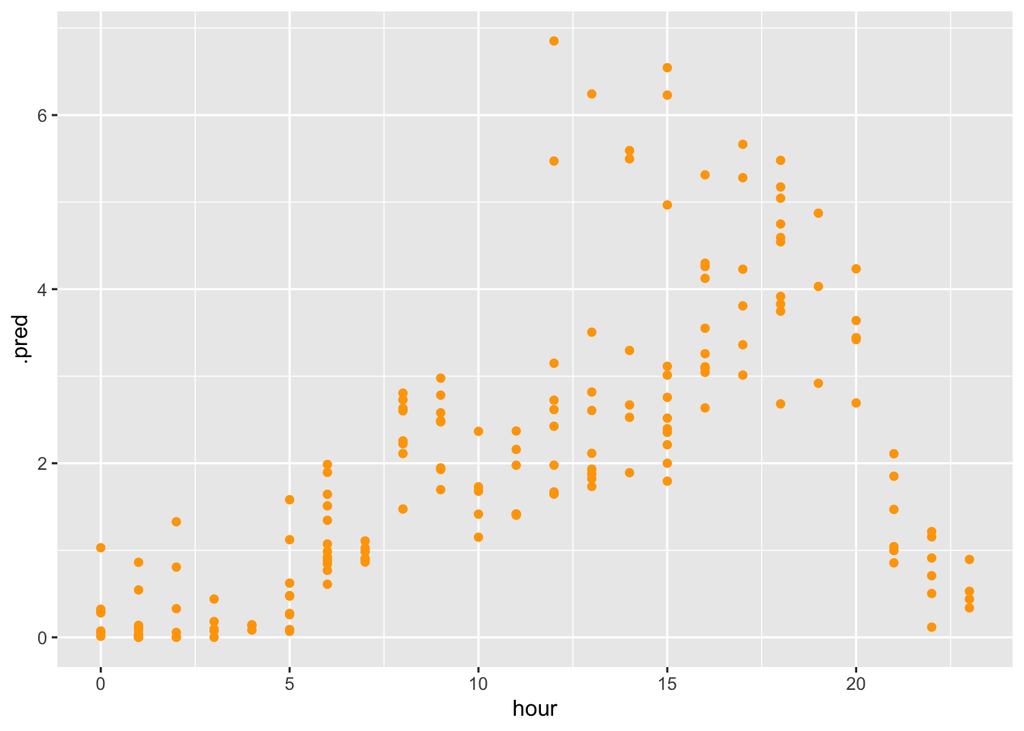

```r
p_test %>%
  filter(month == "Aug" && year == 2021) %>%
  ggplot(aes(x = hour, y = .pred))+
  geom_point(color = "orange")
```

```r
  # geom_smooth()
```

We would need to do more investigation to decide if the model could predict a full station. However, this graph is unique. Between 11 AM and 4 PM there is a gap in the predictions. Perhaps the lower predictions (2-3) are a full station and the higher predictions (5-8) are not full.

## High Demand

```r
filtered_data <- filter_by_distance(data, from_station = '39th_&_calvert_st_nw_/_stoddert', distance_m = 1600)

hour_data <- get_station_hourly(filtered_data) %>%
  get_historic_weather() %>%
  add_sun_is_out()
```

```
## `mutate_all()` ignored the following grouping variables:
## Columns `year`, `month`, `day`, `hour`
## Use `mutate_at(df, vars(-group_cols()), myoperation)` to silence the message.
```

```r
lagged_data <- setup_for_time_prediction(hour_data, station_name = "39th_&_calvert_st_nw_/_stoddert")

model_data <- lagged_data %>%
  add_predictor_times() %>%
  filter(!is.na(departures) & !is.na(arrivals)) %>%
  select(-arrivals) %>%
  format_weather()

# create a split object
data_split <- initial_split(model_data, prop = 0.8)

# create the training and testing data
train <- training(x = data_split)
test  <- testing(x = data_split)
```

```r
recipe <-
  recipe(formula = departures ~ ., data = train) %>%
  step_holiday(date, holidays = timeDate::listHolidays("US"), keep_original_cols = FALSE) %>%
  step_nzv(all_predictors())
  # step_BoxCox(all_outcomes()) # Does not run with zero in the values

final_wf <- workflow() %>%
  add_recipe(recipe) %>%
  add_model(mod) %>%
  fit(train)
p_test <- bind_cols(
  test,
  predict(object = final_wf, new_data = test))
```

## Results

Out of sample RMSE

```r
sqrt(mean((p_test$departures - p_test$.pred)^2))
```

```
## [1] 1.147436
```

```r
mod %>%
  set_engine("ranger", importance = "permutation") %>%
  fit(departures ~ .,
    data = train
  ) %>%
  vip(geom = "point")
```

[output not shown]

## Results

This graph does not show the same unique attribute that the high supply station had. However it does show a lot more variance than the Lincoln Memorial. With more investigation it could be that the low predictions are an empty station and the high predictions are not empty.

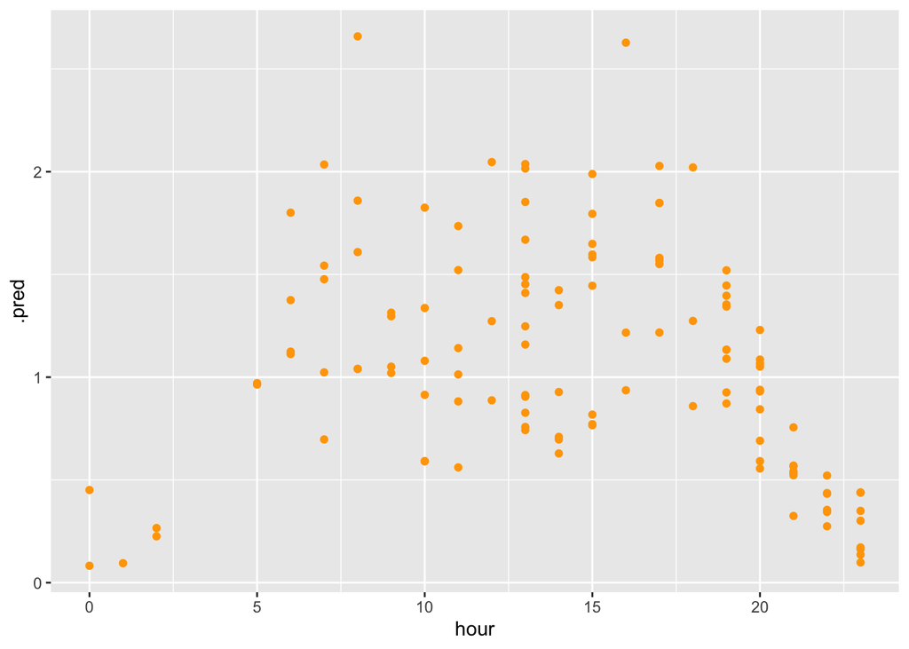

```r
p_test %>%
  filter(month == "Aug" && year == 2021) %>%
  ggplot(aes(x = hour, y = .pred))+
  geom_point(color = "orange")
```

The graph below is an attempt to compare the predicted value vs the overall rides going on in the city. The goal would be that if the overall rides in the city were high, and our predictions were low, perhaps at those times the station was empty. We filter out where all predictors are zero, both to avoid a divide by zero and that this station also had zero (lagged two weeks). This is a very high demand bike station that should be above the average. It could be that the large set of low predictions show an empty station. This would require further analysis.

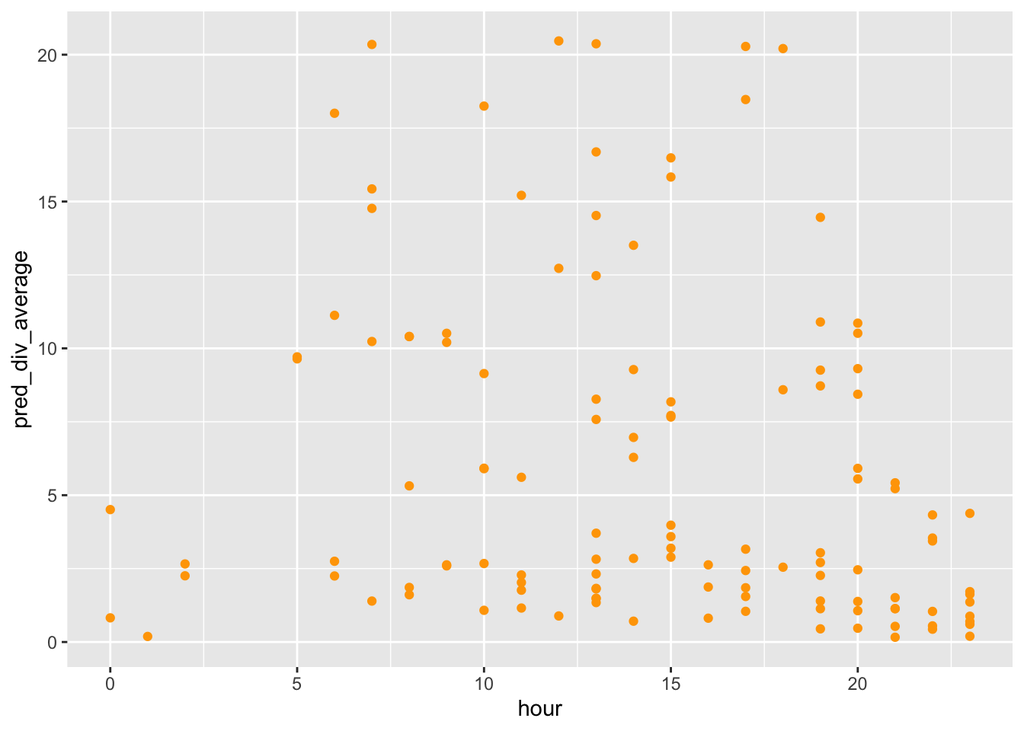

```r
p_test %>%
  mutate(mean = max(mean( `34th_st_&_wisconsin_ave_nw_arrivals`:`connecticut_ave_&_mckinley_st_nw_arrivals`),0.1)) %>%
  filter(mean != 0) %>%
  mutate(pred_div_average = .pred / mean) %>%
  filter(month == "Aug" && year == 2021) %>%
  ggplot(aes(x = hour, y = pred_div_average))+
  geom_point(color = "orange")
```

## last thing

### Ideas for future projects

- Scrape real time data to get station status
- Try xgboost
- Account for the pandemic somehow (for example over the summer 2020 when there was a curfew)
- Try a version where we first implement a random forest model to predict a binary variable of whether bikes are departing or not. Then use the predictions to create a new variable and estimate a second random forest model that uses that variable as a predictor
- Instead of using RMSE, we could use a range of error that we envision for our project (eg. we can aim at always having 3 bikes at a station– and hence our prediction would essentially be whether or not we have 3 bikes!)